# Effect of Weather, Day of Season, and Registration Status on Bike Rentals

STAT 3302: Statistical Modeling for Discovery II

Authors

Colin Farrell

Paarth Mahajan

Aayush Sharma

Tony Zheng

Published

April 29, 2026

## Introduction

Bike rentals vary from day-to-day depending on various weather, temporal, and user conditions. By analyzing which conditions have the greatest effect on the estimated number of rentals, we can find what conditions have an impact or don’t, and how these impacts interact with each other.

#### (RQ.1)

Does the fact that it is a workday (not a weekend/holiday) affect the number of Bike Rentals?

#### (RQ.2)

Do weather conditions affect the number of Bike Rentals among registered users vs. casual users?

#### (RQ.3)

Does the fact that it is a workday (or not) affect the number of Bike Rentals among registered users vs. casual users differently?

#### (RQ.4)

Do the number of rentals change through a season (e.g. do rentals taper off as a season progresses)?

## Data

The Bike Sharing dataset was sourced from (Fanaee-T 2013). It contains the daily and hourly counts of bike rentals in the Capital bike-share system in 2011 and 2012, augmented with weather and temporal information. We use the hourly dataset; it contains a total of 17379 counts.

### Predictors

Dataset predictors used in model fitting: (check appendix for expanded details)

| Predictor | Description |
| --- | --- |
| `temp` | The normalized temperature of the hour (unitless), in $\left[0, 1\right]$ |
| `windspeed` | The normalized windspeed of a day (unitless), in $\left[0, 1\right]$ |
| `hum` | The normalized humidity (unitless), in $\left[0, 1\right]$ |
| `weathersit` | Factor representing the amount/degree of precipitation/cloud cover |
| `season` | Indicator for Season |
| `workingday` | Indicator of if day was a workday or not (1 if workday, 0 if not) |

### Created Predictors

New predictors from the dataset, for model fit:

| Predictor | Description |
| --- | --- |
| `user_type` | Indicator of if the number of rentals is taken from the `casual` or `registered` columns of the dataset (0 if `casual`, 1 if `registered`) |
| Day of season | The day of the season (e.g. 0 for the first day of Spring) |

Our modified dataset then contains 34758 counts (i.e. double that of the original, since each row gets split into two).

Our model also includes the interaction term between all those described in Predictors and `userType`. This is done to see how registered users are affected by each other predictor compared to casual users.

### Exploratory Plots

#### By `workday`

We can look at how RQ.1 and RQ.3 by plotting `workingday` against the rental counts, faceted by both `user_type` and `workingday`. We plot the proportion of counts accounted for by each bin of rentals in each group to see how the distribution itself changes, without it being affected by the total amount of counts in each group.

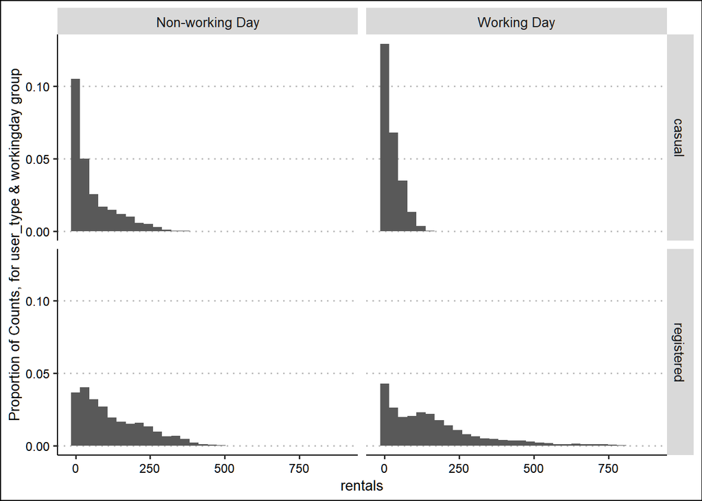

It seems that we generally see a significant change in rentals on working days, but this association is **reversed** for registered users. Casual users tend to see higher rental counts on *non-working* days, but registered users tend to see higher rental counts on *working* days. This suggests that the answer to RQ.3 might be that registered and casual users **are** affected by working days differently.

#### By `user_type`

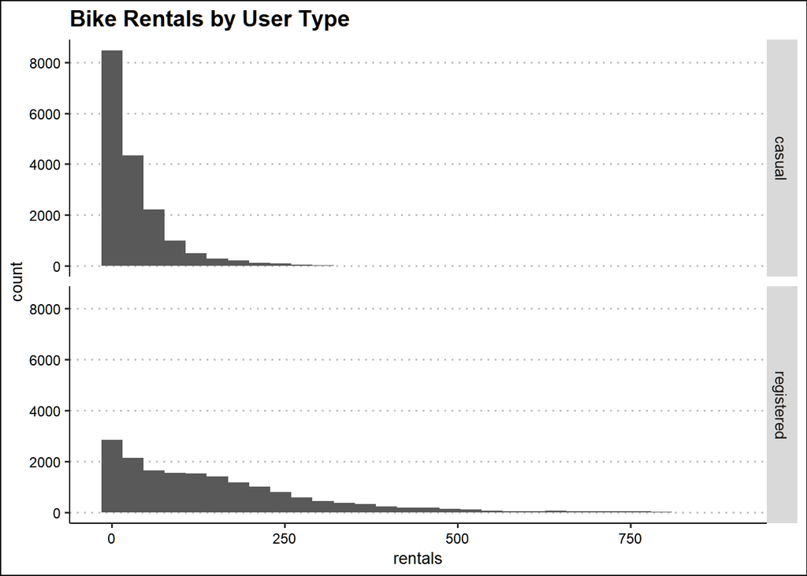

It seems that the distribution of registered rentals is skewed higher than for casual users: casual counts are higher when the # of rentals is less than about 100, but registered counts are higher for rentals greater than that. In other words, it seems that `user_type` has an impact on the total number of rentals.

#### By `temp`

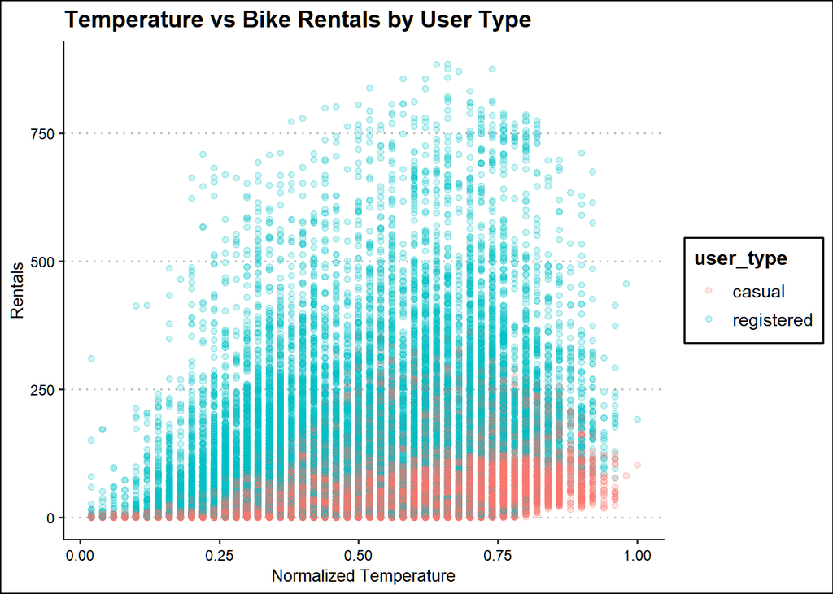

We can see that registered users generally have a higher baseline usage from casual users, even when comparing rentals for registered users at lower temperatures to casual users at higher temperatures.

#### By `day_of_season`

We can explore RQ.4 by plotting the `day_of_season` against the rental counts.

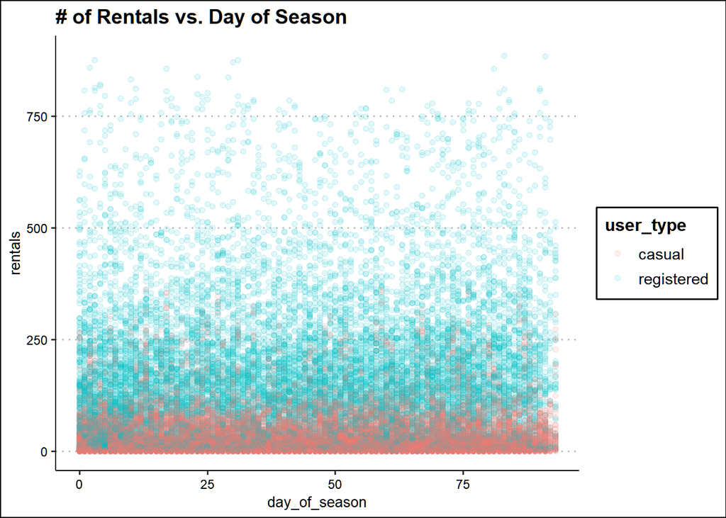

It doesn’t seem that there’s a strong relationship here; regardless of how far a season is along, it seems that the distribution of rentals stays relatively constant.

## Methods

### Model

We fit model
$$Y_i \sim \text{Poisson}(\lambda_i)$$

with the log-rate link function
$$\log(\lambda_i) = X_i^T\beta$$

for $i \in \{1, 2, \dots, n\}$.

$Y_i$ is the independent observed number of bike rentals for the hour of the $i$-th observation. For each hour, there are two $Y$ based on the type of user (registered/casual).

Then, $X_i \in \mathbb{R}^{(p+1)}$ and $\beta \in \mathbb{R}^{p + 1}$, where:

- $n$ is the number of samples in the **hour dataset** times two (for each type of user)
- $p$ is the total number of predictors we’re including
- $X_{i, j}$ correspond to the value $j$-th predictor for observation $i$, where $X_{i,1}=1$ for all $i$

We also use `stepAIC` (bidirectional stepwise model selection using AIC) to determine if our model would have a better fit by ablating any predictors.

## Results

We get fitted model:

```
Call:
glm(formula = rentals ~ (temp + windspeed + hum + weathersit +
    workingday + day_of_season + season) * user_type, family = poisson(),
    data = bike_transformed)

Coefficients:
                                    Estimate Std. Error  z value Pr(>|z|)
(Intercept)                        2.906e+00  8.519e-03  341.176  < 2e-16 ***
temp                               3.621e+00  1.125e-02  321.782  < 2e-16 ***
windspeed                          3.365e-01  1.097e-02   30.674  < 2e-16 ***
hum                               -2.105e+00  8.145e-03 -258.460  < 2e-16 ***
weathersit2                        1.345e-01  3.258e-03   41.295  < 2e-16 ***
weathersit3                       -1.025e-01  7.111e-03  -14.407  < 2e-16 ***
weathersit4                       -3.154e-01  3.536e-01   -0.892   0.3724
workingday                        -8.667e-01  2.547e-03 -340.287  < 2e-16 ***
day_of_season                      1.526e-03  5.026e-05   30.366  < 2e-16 ***
seasonSum                          3.534e-01  5.628e-03   62.805  < 2e-16 ***
seasonAut                         -4.757e-02  6.565e-03   -7.246 4.28e-13 ***
seasonWin                          5.619e-01  5.233e-03  107.378  < 2e-16 ***
user_typeregistered                1.416e+00  9.352e-03  151.439  < 2e-16 ***
temp:user_typeregistered          -1.714e+00  1.239e-02 -138.311  < 2e-16 ***
windspeed:user_typeregistered     -5.115e-02  1.218e-02   -4.201 2.66e-05 ***
hum:user_typeregistered            8.173e-01  8.988e-03   90.930  < 2e-16 ***
weathersit2:user_typeregistered   -5.280e-02  3.591e-03  -14.704  < 2e-16 ***
weathersit3:user_typeregistered   -5.399e-02  7.712e-03   -7.001 2.55e-12 ***
weathersit4:user_typeregistered    7.505e-01  3.601e-01    2.084   0.0372 *
workingday:user_typeregistered     1.139e+00  2.909e-03  391.404  < 2e-16 ***
day_of_season:user_typeregistered  8.852e-04  5.552e-05   15.943  < 2e-16 ***
seasonSum:user_typeregistered     -2.916e-01  6.119e-03  -47.652  < 2e-16 ***
seasonAut:user_typeregistered     -1.608e-02  7.161e-03   -2.246   0.0247 *
seasonWin:user_typeregistered     -1.199e-01  5.640e-03  -21.260  < 2e-16 ***
---
Signif. codes:  0 '***' 0.001 '**' 0.01 '*' 0.05 '.' 0.1 ' ' 1

(Dispersion parameter for poisson family taken to be 1)

    Null deviance: 4643075  on 34757  degrees of freedom
Residual deviance: 2177102  on 34734  degrees of freedom
AIC: 2358946

Number of Fisher Scoring iterations: 5
```

Which is the same after running `stepAIC` (backwards + forwards stepwise AIC model selection) starting from the full model and from the null model.

## Diagnostics

We can generate a diagnostic plot for the estimated log rentals against residuals (for both Pearson and deviance residuals)

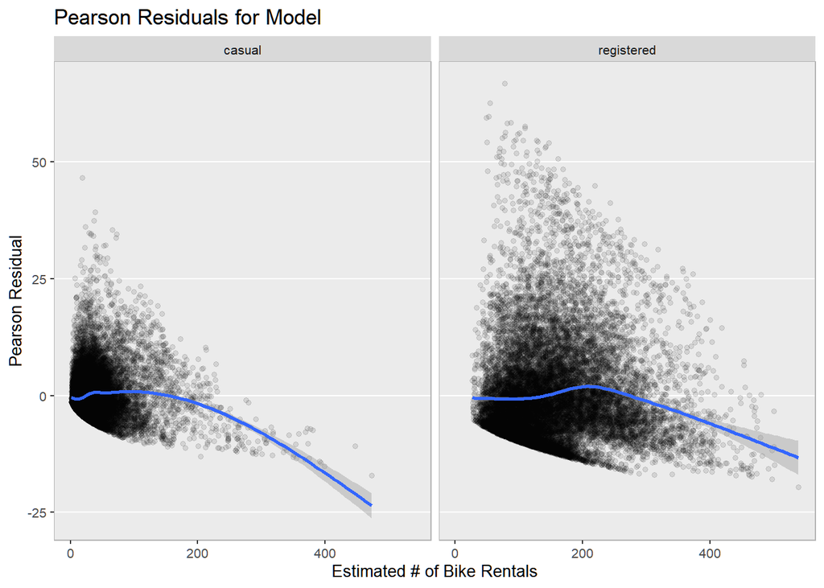

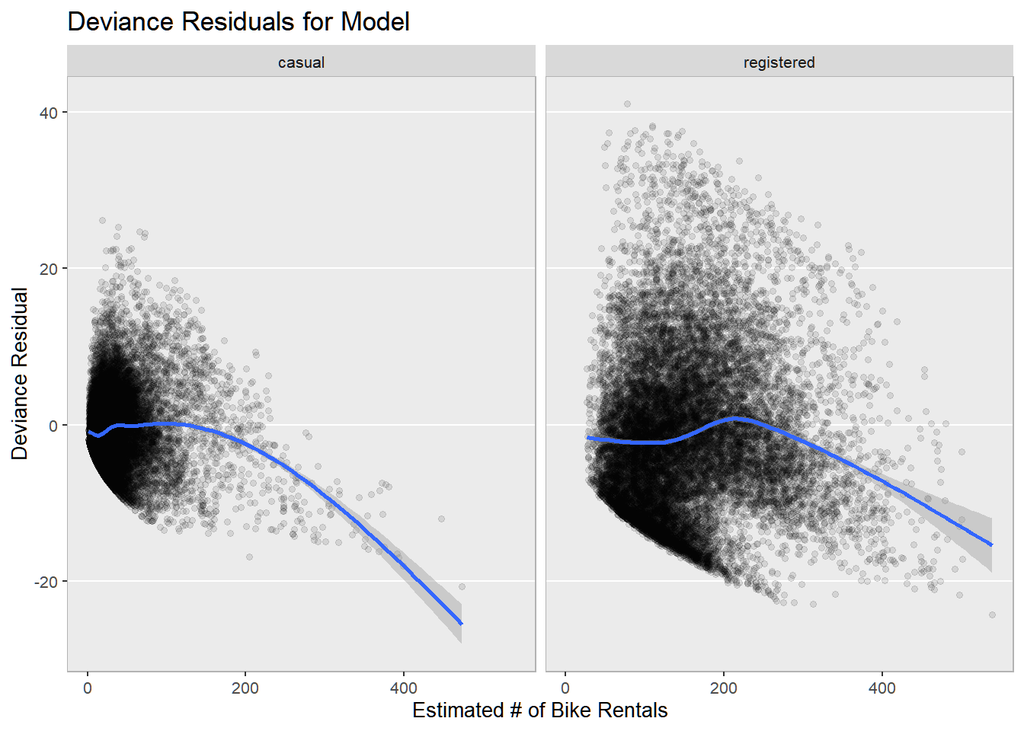

It appears that our model’s residuals are fairly well-fitted for low to medium amounts of bike rentals (0 to about 200). They seem to be centered around 0 for both Pearson and deviance.

For larger values, it appears that both types of residual are biased negatively, which means that our model is sometimes overestimating the number of rentals. This means that our model might not be appropriate; possible causes might be that there is some factor that causes bike rentals to be lower in these cases, or that our predictors are not truly linear (e.g. it might be that a more accurate relationship would be that $\log(\mathbb{E}(rentals))$ is proportional to the log of temperature, rather than the actual temperature).

## Discussion

### (RQ.1)

Workdays had an effect on the average number of rides, as the coefficient is statistically significant with associated p-value

```
[1] 0
```

and the model is statistically significant compared to the model without both workday coefficients, having p-value on the two predictors

```
[1] 0
```

The coefficient value for the `workingday` predictor is

```
workingday
-0.8666524
```

Therefore, the estimated multiplicative change in mean number of riders when it is a working day compared to a non-working day, i.e., a holiday or weekend, is given by

```
[1] 0.4203564
```

which means that approximately 58% less average rides are estimated on a workday compared to a non-workday.

### (RQ.2)

Does Weather affect casual users differently than registered users?

Coefficient summary for all weather conditions:

```
                                   Estimate      Pr(>|z|)
temp                             3.62107496  0.000000e+00
windspeed                        0.33645858 1.283160e-206
hum                             -2.10528547  0.000000e+00
weathersit2                      0.13452269  0.000000e+00
weathersit3                     -0.10245495  4.652071e-47
weathersit4                     -0.31541842  3.723710e-01
temp:user_typeregistered        -1.71388807  0.000000e+00
windspeed:user_typeregistered   -0.05114854  2.663021e-05
hum:user_typeregistered          0.81732178  0.000000e+00
weathersit2:user_typeregistered -0.05279786  6.048806e-49
weathersit3:user_typeregistered -0.05398828  2.549040e-12
weathersit4:user_typeregistered  0.75046453  3.716471e-02
```

Weather conditions affect both groups of users, but casual users are substantially more sensitive to weather than registered users. For example, the estimated mean rentals registered users are less affected by the temperature: the coefficient for temperature (i.e. the factor by which the estimated log mean number of rentals increases for unit of normalized temperature) for casual users is 3.62 vs. (3.62 + -1.71 = 1.91) for registered users.

The same goes for humidity, with estimated casual humidity coefficient -2.11 vs. registered humidity coefficient (-2.11 + 0.82 = -1.29).

For windspeed, the estimated casual coefficient was 0.34 vs. registered windspeedidity coefficient (0.34 + -0.05 = 0.29).

Finally, for precipitation, the casual coefficients were

```
weathersit2 weathersit3 weathersit4
  0.1345227  -0.1024549  -0.3154184
```

versus

[output not shown]

All of `temp`, `hum`, and `windspeed` (and their respective interaction terms with `user_type`) were statistically significant, with low p-values, which means that these observed relationships were significant. This was also true for each of the seasons and their interactions terms, except for the baseline coefficient for heavy precipitation (though its interaction term was significant). This indicates that there was not a statistically significant difference in bike rentals among casual users between a heavy precipitation versus. clear day, though this could be due to high collinearity between such conditions and other weather conditions (like windspeed and humidity).

### (RQ.3)

We want to know if workday status affects the bike rentals of casual and registered users differently.

The estimates for this interaction effect coefficient during model fit:

```
                                 Estimate  Std. Error Pr(>|z|)
workingday                     -0.8666524 0.002546827        0
workingday:user_typeregistered  1.1386038 0.002909022        0
user_typeregistered             1.4163179 0.009352376        0
```

```
Casual Multiplicative Difference in Rentals for Workingday:    0.42
```

```
Registered Multiplicative Difference in Rentals for Workingday: 1.313
```

We illustrate the multiplicative difference in rentals between Working and non-Working days for Casual and Registered users above. We visualize this below:

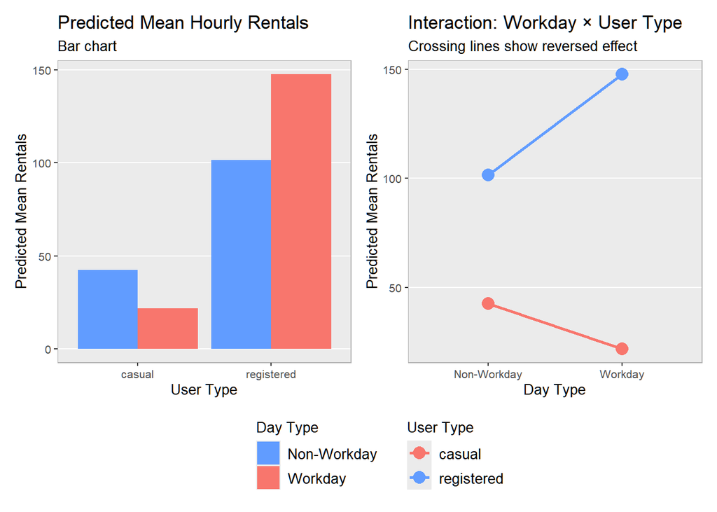

This suggests that more registered users might use bike sharing more on workdays (for commute/exercise) while casual users might use the service for recreation on holidays/weekends.

The Analysis of Deviance Table (provided in the appendix), shows that including the interaction reduces the residual deviance from the reduced model by 151,556, providing strong evidence that workday status affects casual and registered users differently. We can thus say that there is a practically meaningful difference in relationships registered/casual bike users have with working days.

### (RQ.4)

Our estimated `day_of_season` coefficients were statistically significant, since `day_of_season` and `day_of_season:user_typeregistered` had individual p-values of

```
                    day_of_season day_of_season:user_typeregistered
                    1.563248e-202                      3.162649e-57
```

and a p-value when added together

```
[1] 0
```

with individual values

```
                    day_of_season day_of_season:user_typeregistered
                     0.0015263168                      0.0008852259
```

These indicate that there was a positive relationship between the day of the season and average bike rentals. Under this, bike rentals increased in later parts of seasons for all users - though to a slightly greater extent for registered users. Specifically, it is estimated that for every day that passed in a season, the estimated mean number of casual bike rentals in an hour increased by a factor of

```
[1] 1.001527
```

and for registered users

```
[1] 1.002414
```

However, these values are very small, especially since this effect prorated over an entire season (about 90 days) would only result in a multiplicative increase in bike rentals by

```
[1] 1.242392
```

which is a fairly small increase. Therefore, even though the coefficient is statistically significant, it would seem that there isn’t a practically significant effect on rentals, with weather and `user_type` having a much greater effect on the number of rentals.

## Conclusion

Bike rentals are significantly associated with different climate/weather conditions. They

- Significantly increased for higher temperatures
- Increased for non-working days

In addition, registered users tended to behave differently from casual users, with registered users often having a dampened or even reversed relationship between weather predictors and working days. Registered users were generally less affected by the weather, and saw an increase in rentals on working days compared to the decrease seen in casual users.

## Limitations

Our residual deviance suggests substantial over-dispersion (which violates our mean equals variance assumption for Poisson Regression), thus models like Quasi-Poisson models may be worth exploring. Our diagnostics also show the model overestimating at high rental counts, which could be fixed by applying a relevant transform to one of our predictors. Finally, hours within the same day can be temporally dependent and correlated, violating our independence assumption; this can be solved with models meant to address time-series data.

## References

Fanaee-T, Hadi. 2013. “Bike Sharing.” UCI Machine Learning Repository.

## Appendix

The model was fit using

```r
model = glm(rentals ~ (temp + windspeed + hum + weathersit + workingday + day_of_season + season)*user_type, bike_transformed, family = poisson())

s = summary(model)
s
```

Analysis of Deviance Table (to check if the Interaction effect between Working day and User Type)

```
Analysis of Deviance Table

Model 1: rentals ~ (temp + windspeed + hum + weathersit + day_of_season +
    season) * user_type + workingday + user_type
Model 2: rentals ~ (temp + windspeed + hum + weathersit + workingday +
    day_of_season + season) * user_type
  Resid. Df Resid. Dev Df Deviance  Pr(>Chi)
1     34735    2328658
2     34734    2177102  1   151556 < 2.2e-16 ***
---
Signif. codes:  0 '***' 0.001 '**' 0.01 '*' 0.05 '.' 0.1 ' ' 1
```

Expanded Predictor Information

Dataset predictors we used are described below

[output not shown]

We also create new predictors from the dataset, described below

[output not shown]